# p8130_hw5

Catherine

12/2/2018

## Problem 1

Explore the dataset and generate appropriate descriptive statistics and relevant graphs for all variables of interest (continuous and categorical) – no test required.

```r
state_data = state.x77 %>% as.tibble() %>% janitor::clean_names()

summary_df = skimr::skim_to_wide(state_data) %>%
  mutate(min = p0, max = p100, median = p50, IQR = (as.numeric(p75) - as.numeric(p25)), range = (as.numeric(p100) - as.numeric(p0))) %>%
  select(type, variable, mean, sd, min, median, max, range, IQR, hist)

knitr::kable(summary_df, digits = 3, caption = "Descriptive Statistics for All Variables")
```

Descriptive Statistics for All Variables

| type | variable | mean | sd | min | median | max | range | IQR | hist |
| --- | --- | --- | --- | --- | --- | --- | --- | --- | --- |
| numeric | area | 70735.88 | 85327.3 | 1049 | 54277 | 566432 | 565383.00 | 44177.25 | ▇▃▁▁▁▁▁▁ |
| numeric | frost | 104.46 | 51.98 | 0 | 114.5 | 188 | 188.00 | 73.50 | ▃▂▃▂▅▇▃▅ |
| numeric | hs_grad | 53.11 | 8.08 | 37.8 | 53.25 | 67.3 | 29.50 | 11.10 | ▅▂▂▃▇▇▃▂ |
| numeric | illiteracy | 1.17 | 0.61 | 0.5 | 0.95 | 2.8 | 2.30 | 0.96 | ▇▃▃▂▂▂▁▁ |
| numeric | income | 4435.8 | 614.47 | 3098 | 4519 | 6315 | 3217.00 | 820.75 | ▁▅▅▇▆▃▁▁ |
| numeric | life_exp | 70.88 | 1.34 | 67.96 | 70.67 | 73.6 | 5.64 | 1.77 | ▂▂▁▇▃▅▃▂ |
| numeric | murder | 7.38 | 3.69 | 1.4 | 6.85 | 15.1 | 13.70 | 6.32 | ▆▃▅▃▂▇▂▁ |
| numeric | population | 4246.42 | 4464.49 | 365 | 2838.5 | 21198 | 20833.00 | 3889.00 | ▇▅▁▁▁▁▁▁ |

**Comment**

All the variables are continuous. Therefore, I chose mean and median as measures of location, range, IQR and sd as measures of dispersion.

```r
cor(state_data) %>% knitr::kable(digits = 3, caption = "Correlation Table")
```

Correlation Table

|  | population | income | illiteracy | life_exp | murder | hs_grad | frost | area |
| --- | --- | --- | --- | --- | --- | --- | --- | --- |
| population | 1.000 | 0.208 | 0.108 | -0.068 | 0.344 | -0.098 | -0.332 | 0.023 |
| income | 0.208 | 1.000 | -0.437 | 0.340 | -0.230 | 0.620 | 0.226 | 0.363 |
| illiteracy | 0.108 | -0.437 | 1.000 | -0.588 | 0.703 | -0.657 | -0.672 | 0.077 |
| life_exp | -0.068 | 0.340 | -0.588 | 1.000 | -0.781 | 0.582 | 0.262 | -0.107 |
| murder | 0.344 | -0.230 | 0.703 | -0.781 | 1.000 | -0.488 | -0.539 | 0.228 |
| hs_grad | -0.098 | 0.620 | -0.657 | 0.582 | -0.488 | 1.000 | 0.367 | 0.334 |
| frost | -0.332 | 0.226 | -0.672 | 0.262 | -0.539 | 0.367 | 1.000 | 0.059 |
| area | 0.023 | 0.363 | 0.077 | -0.107 | 0.228 | 0.334 | 0.059 | 1.000 |

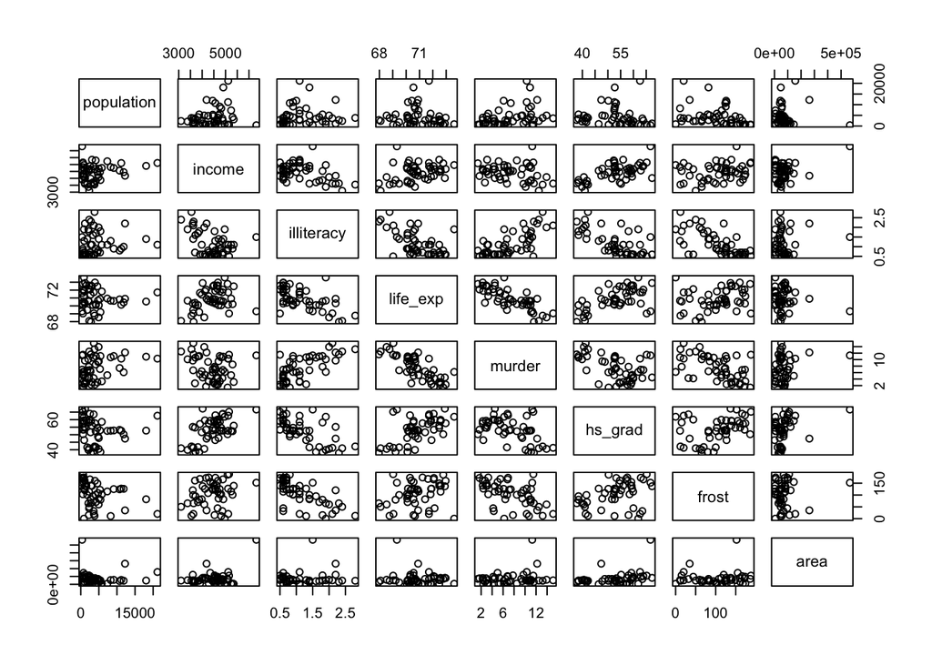

```r
pairs(state_data)
```

**Comment**

From the table, `life_exp` and `murder` have a strong negative correlation. Also, `murder` has a strong positive correaltion with `illiteracy`, which need more investigation.

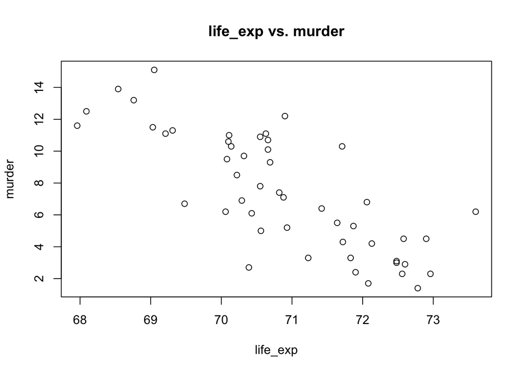

```r
state_data %>%
  select(life_exp, murder) %>%
  plot(main = "life_exp vs. murder")
```

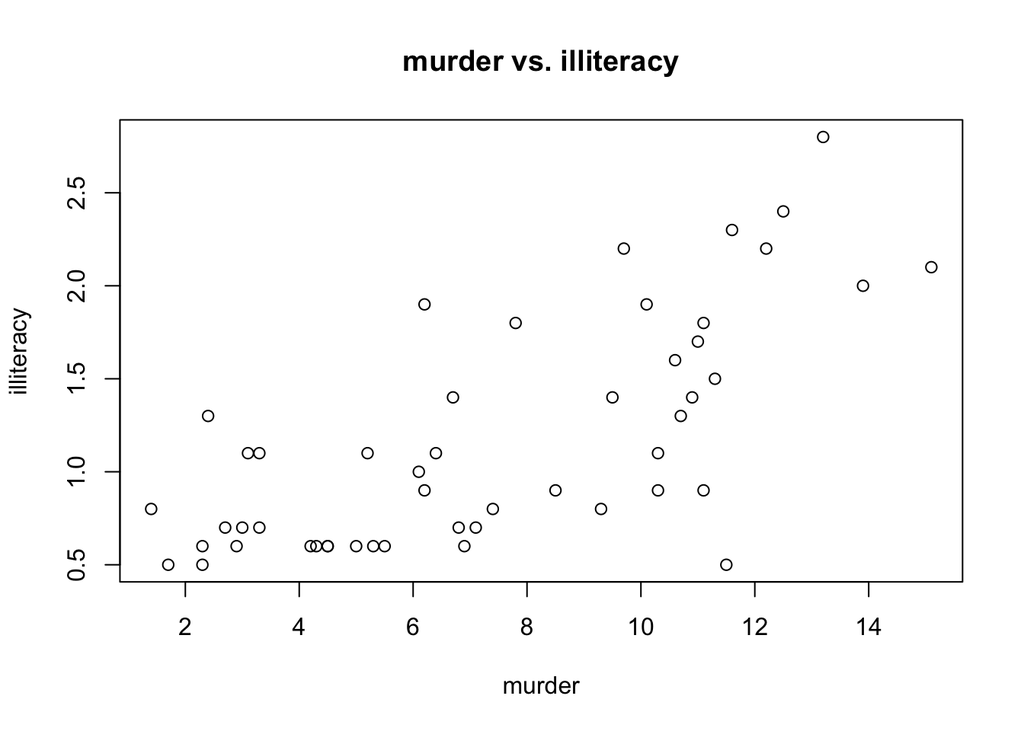

```r
state_data %>%
  select(murder, illiteracy) %>%
  plot(main = "murder vs. illiteracy")
```

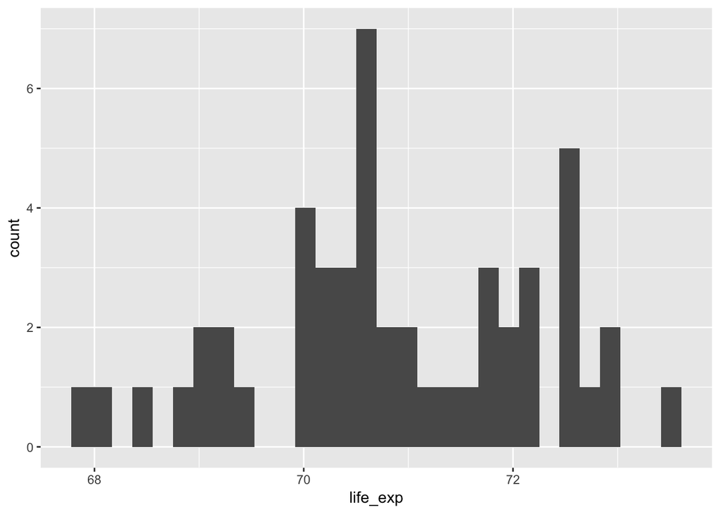

```r
state_data %>%
  ggplot(aes(x = life_exp)) +
  geom_histogram()
```

**Comment**

Make plot to show the correlation between `life_exp` and `murder`, `murder` and `illiteracy`. Also, check the distribution of `life_exp`, which is approximately normal distribution. I decided not to do any transformation.

## Problem 2

Use automatic procedures to find a ‘best subset’ of the full model.

```r
fit_all = lm(life_exp ~ ., data = state_data)
summary(fit_all)$coef %>% knitr::kable()
```

|  | Estimate | Std. Error | t value | Pr(>\|t\|) |
| --- | --- | --- | --- | --- |
| (Intercept) | 70.9432241 | 1.7479754 | 40.5859402 | 0.0000000 |
| population | 0.0000518 | 0.0000292 | 1.7747731 | 0.0831835 |
| income | -0.0000218 | 0.0002444 | -0.0892060 | 0.9293422 |
| illiteracy | 0.0338203 | 0.3662799 | 0.0923346 | 0.9268712 |
| murder | -0.3011232 | 0.0466207 | -6.4589973 | 0.0000001 |
| hs_grad | 0.0489295 | 0.0233233 | 2.0978818 | 0.0419718 |
| frost | -0.0057350 | 0.0031432 | -1.8245568 | 0.0751868 |
| area | -0.0000001 | 0.0000017 | -0.0442593 | 0.9649075 |

### Backward elimination

Take out non-significant variables, starting with the highest p-value

```r
# No area
step1 = update(fit_all, . ~ . -area)
summary(step1)
```

```
##
## Call:
## lm(formula = life_exp ~ population + income + illiteracy + murder +
##     hs_grad + frost, data = state_data)
##
## Residuals:
##      Min       1Q   Median       3Q      Max
## -1.49047 -0.52533 -0.02546  0.57160  1.50374
##
## Coefficients:
##               Estimate Std. Error t value Pr(>|t|)
## (Intercept)  7.099e+01  1.387e+00  51.165  < 2e-16 ***
## population   5.188e-05  2.879e-05   1.802   0.0785 .
## income      -2.444e-05  2.343e-04  -0.104   0.9174
## illiteracy   2.846e-02  3.416e-01   0.083   0.9340
## murder      -3.018e-01  4.334e-02  -6.963 1.45e-08 ***
## hs_grad      4.847e-02  2.067e-02   2.345   0.0237 *
## frost       -5.776e-03  2.970e-03  -1.945   0.0584 .
## ---
## Signif. codes:  0 '***' 0.001 '**' 0.01 '*' 0.05 '.' 0.1 ' ' 1
##
## Residual standard error: 0.7361 on 43 degrees of freedom
## Multiple R-squared:  0.7361, Adjusted R-squared:  0.6993
## F-statistic: 19.99 on 6 and 43 DF,  p-value: 5.362e-11
```

```r
# No income
step2 = update(step1, . ~ . -income)
summary(step2)
```

```
##
## Call:
## lm(formula = life_exp ~ population + illiteracy + murder + hs_grad +
##     frost, data = state_data)
##
## Residuals:
##      Min       1Q   Median       3Q      Max
## -1.47248 -0.54771 -0.02936  0.58145  1.49381
##
## Coefficients:
##               Estimate Std. Error t value Pr(>|t|)
## (Intercept)  7.095e+01  1.319e+00  53.786  < 2e-16 ***
## population   5.090e-05  2.691e-05   1.892   0.0651 .
## illiteracy   2.906e-02  3.377e-01   0.086   0.9318
## murder      -3.020e-01  4.282e-02  -7.053 9.57e-09 ***
## hs_grad      4.733e-02  1.732e-02   2.733   0.0090 **
## frost       -5.806e-03  2.923e-03  -1.986   0.0532 .
## ---
## Signif. codes:  0 '***' 0.001 '**' 0.01 '*' 0.05 '.' 0.1 ' ' 1
##
## Residual standard error: 0.7278 on 44 degrees of freedom
## Multiple R-squared:  0.7361, Adjusted R-squared:  0.7061
## F-statistic: 24.54 on 5 and 44 DF,  p-value: 1.021e-11
```

```r
# No illiteracy
step3 = update(step2, . ~ . -illiteracy)
summary(step3)
```

```
##
## Call:
## lm(formula = life_exp ~ population + murder + hs_grad + frost,
##     data = state_data)
##
## Residuals:
##      Min       1Q   Median       3Q      Max
## -1.47095 -0.53464 -0.03701  0.57621  1.50683
##
## Coefficients:
##               Estimate Std. Error t value Pr(>|t|)
## (Intercept)  7.103e+01  9.529e-01  74.542  < 2e-16 ***
## population   5.014e-05  2.512e-05   1.996  0.05201 .
## murder      -3.001e-01  3.661e-02  -8.199 1.77e-10 ***
## hs_grad      4.658e-02  1.483e-02   3.142  0.00297 **
## frost       -5.943e-03  2.421e-03  -2.455  0.01802 *
## ---
## Signif. codes:  0 '***' 0.001 '**' 0.01 '*' 0.05 '.' 0.1 ' ' 1
##
## Residual standard error: 0.7197 on 45 degrees of freedom
## Multiple R-squared:  0.736,  Adjusted R-squared:  0.7126
## F-statistic: 31.37 on 4 and 45 DF,  p-value: 1.696e-12
```

```r
# No population
step4 = update(step3, . ~ . -population)
summary(step4)
```

```
##
## Call:
## lm(formula = life_exp ~ murder + hs_grad + frost, data = state_data)
##
## Residuals:
##     Min      1Q  Median      3Q     Max
## -1.5015 -0.5391  0.1014  0.5921  1.2268
##
## Coefficients:
##              Estimate Std. Error t value Pr(>|t|)
## (Intercept) 71.036379   0.983262  72.246  < 2e-16 ***
## murder      -0.283065   0.036731  -7.706 8.04e-10 ***
## hs_grad      0.049949   0.015201   3.286  0.00195 **
## frost       -0.006912   0.002447  -2.824  0.00699 **
## ---
## Signif. codes:  0 '***' 0.001 '**' 0.01 '*' 0.05 '.' 0.1 ' ' 1
##
## Residual standard error: 0.7427 on 46 degrees of freedom
## Multiple R-squared:  0.7127, Adjusted R-squared:  0.6939
## F-statistic: 38.03 on 3 and 46 DF,  p-value: 1.634e-12
```

**Comment**

From the Backward elimination, we got `life_exp ~ population + murder + hs_grad + frost`. I keep the `population` as it contributes to the goodness of fit for the model.

**life expectancy = 71 - 0.3murder + 0.0466hs_grad + -0.00594frost + 0.0000501population**

### Forward elimination

Take in significant variables, starting with the lowest p-value

*Step 1:* Fit simple linear regressions for all variables,look for the variable with lowest p-value

```r
fit1 = lm(life_exp ~ population, data = state_data)
tidy(fit1)
```

```
## # A tibble: 2 x 5
##   term           estimate std.error statistic  p.value
##   <chr>             <dbl>     <dbl>     <dbl>    <dbl>
## 1 (Intercept)  71.0       0.265       267.    7.90e-78
## 2 population   -0.0000205 0.0000433    -0.473 6.39e- 1
```

```r
fit2 = lm(life_exp ~ income, data = state_data)
tidy(fit2)
```

```
## # A tibble: 2 x 5
##   term         estimate std.error statistic  p.value
##   <chr>           <dbl>     <dbl>     <dbl>    <dbl>
## 1 (Intercept) 67.6       1.33         50.9  1.98e-43
## 2 income       0.000743  0.000297      2.51 1.56e- 2
```

```r
fit3 = lm(life_exp ~ illiteracy, data = state_data)
tidy(fit3)
```

```
## # A tibble: 2 x 5
##   term        estimate std.error statistic  p.value
##   <chr>          <dbl>     <dbl>     <dbl>    <dbl>
## 1 (Intercept)    72.4      0.338    214.   3.47e-73
## 2 illiteracy     -1.30     0.257     -5.04 6.97e- 6
```

```r
fit4 = lm(life_exp ~ murder, data = state_data)
tidy(fit4)
```

```
## # A tibble: 2 x 5
##   term        estimate std.error statistic  p.value
##   <chr>          <dbl>     <dbl>     <dbl>    <dbl>
## 1 (Intercept)   73.0      0.270     270.   4.72e-78
## 2 murder        -0.284    0.0328     -8.66 2.26e-11
```

```r
fit5 = lm(life_exp ~ hs_grad, data = state_data)
tidy(fit5)
```

```
## # A tibble: 2 x 5
##   term        estimate std.error statistic  p.value
##   <chr>          <dbl>     <dbl>     <dbl>    <dbl>
## 1 (Intercept)  65.7       1.05       62.8  9.92e-48
## 2 hs_grad       0.0968    0.0195      4.96 9.20e- 6
```

```r
fit6 = lm(life_exp ~ frost, data = state_data)
tidy(fit6)
```

```
## # A tibble: 2 x 5
##   term        estimate std.error statistic  p.value
##   <chr>          <dbl>     <dbl>     <dbl>    <dbl>
## 1 (Intercept) 70.2       0.419      168.   4.33e-68
## 2 frost        0.00677   0.00360      1.88 6.60e- 2
```

*Step 2:* Enter first the one with the lowest p-value: murder. Enter the one with the lowest p-value in the rest

```r
forward1 = lm(life_exp ~ murder, data = state_data)
tidy(forward1)
```

```
## # A tibble: 2 x 5
##   term        estimate std.error statistic  p.value
##   <chr>          <dbl>     <dbl>     <dbl>    <dbl>
## 1 (Intercept)   73.0      0.270     270.   4.72e-78
## 2 murder        -0.284    0.0328     -8.66 2.26e-11
```

```r
fit1 = update(forward1, . ~ . + illiteracy)
tidy(fit1)
```

```
## # A tibble: 3 x 5
##   term        estimate std.error statistic  p.value
##   <chr>          <dbl>     <dbl>     <dbl>    <dbl>
## 1 (Intercept)   73.0      0.286    256.    1.56e-75
## 2 murder        -0.264    0.0464    -5.69  7.96e- 7
## 3 illiteracy    -0.172    0.281     -0.613 5.43e- 1
```

```r
fit2 = update(forward1, . ~ . + hs_grad)
tidy(fit2)
```

```
## # A tibble: 3 x 5
##   term        estimate std.error statistic  p.value
##   <chr>          <dbl>     <dbl>     <dbl>    <dbl>
## 1 (Intercept)  70.3       1.02       69.2  5.91e-49
## 2 murder       -0.237     0.0353     -6.72 2.18e- 8
## 3 hs_grad       0.0439    0.0161      2.72 9.09e- 3
```

```r
fit3 = update(forward1, . ~ . + income)
tidy(fit3)
```

```
## # A tibble: 3 x 5
##   term          estimate std.error statistic  p.value
##   <chr>            <dbl>     <dbl>     <dbl>    <dbl>
## 1 (Intercept)  71.2       0.967        73.6  3.32e-50
## 2 murder       -0.270     0.0328       -8.21 1.22e-10
## 3 income        0.000370  0.000197      1.88 6.66e- 2
```

```r
fit4 = update(forward1, . ~ . + frost)
tidy(fit4)
```

```
## # A tibble: 3 x 5
##   term         estimate std.error statistic  p.value
##   <chr>           <dbl>     <dbl>     <dbl>    <dbl>
## 1 (Intercept)  73.9       0.500      148.   2.36e-64
## 2 murder       -0.328     0.0375      -8.74 2.05e-11
## 3 frost        -0.00578   0.00266     -2.17 3.52e- 2
```

```r
fit5 = update(forward1, . ~ . + population)
tidy(fit5)
```

```
## # A tibble: 3 x 5
##   term           estimate std.error statistic  p.value
##   <chr>             <dbl>     <dbl>     <dbl>    <dbl>
## 1 (Intercept)  72.9       0.258        282.   1.55e-77
## 2 murder       -0.312     0.0332        -9.42 2.15e-12
## 3 population    0.0000683 0.0000274      2.49 1.64e- 2
```

*Step 3:* Enter the one with the lowest p-value: hs_grad. Enter the one with the lowest p-value in the rest.

```r
forward2 = update(forward1, . ~ . + hs_grad)
tidy(forward2)
```

```
## # A tibble: 3 x 5
##   term        estimate std.error statistic  p.value
##   <chr>          <dbl>     <dbl>     <dbl>    <dbl>
## 1 (Intercept)  70.3       1.02       69.2  5.91e-49
## 2 murder       -0.237     0.0353     -6.72 2.18e- 8
## 3 hs_grad       0.0439    0.0161      2.72 9.09e- 3
```

```r
fit1 = update(forward2, . ~ . + illiteracy)
tidy(fit1)
```

```
## # A tibble: 4 x 5
##   term        estimate std.error statistic  p.value
##   <chr>          <dbl>     <dbl>     <dbl>    <dbl>
## 1 (Intercept)  69.7       1.22      57.1   2.41e-44
## 2 murder       -0.258     0.0435    -5.93  3.63e- 7
## 3 hs_grad       0.0518    0.0188     2.76  8.25e- 3
## 4 illiteracy    0.254     0.305      0.833 4.09e- 1
```

```r
fit2 = update(forward2, . ~ . + income)
tidy(fit2)
```

```
## # A tibble: 4 x 5
##   term           estimate std.error statistic  p.value
##   <chr>             <dbl>     <dbl>     <dbl>    <dbl>
## 1 (Intercept)  70.1        1.10        64.0   1.33e-46
## 2 murder       -0.239      0.0358      -6.66  2.92e- 8
## 3 hs_grad       0.0391     0.0203       1.92  6.05e- 2
## 4 income        0.0000953  0.000239     0.398 6.92e- 1
```

```r
fit3 = update(forward2, . ~ . + frost)
tidy(fit3)
```

```
## # A tibble: 4 x 5
##   term         estimate std.error statistic  p.value
##   <chr>           <dbl>     <dbl>     <dbl>    <dbl>
## 1 (Intercept)  71.0       0.983       72.2  5.25e-49
## 2 murder       -0.283     0.0367      -7.71 8.04e-10
## 3 hs_grad       0.0499    0.0152       3.29 1.95e- 3
## 4 frost        -0.00691   0.00245     -2.82 6.99e- 3
```

```r
fit4 = update(forward2, . ~ . + population)
tidy(fit4)
```

```
## # A tibble: 4 x 5
##   term           estimate std.error statistic  p.value
##   <chr>             <dbl>     <dbl>     <dbl>    <dbl>
## 1 (Intercept)  70.4       0.969         72.7  3.95e-49
## 2 murder       -0.266     0.0357        -7.45 1.91e- 9
## 3 hs_grad       0.0407    0.0154         2.64 1.12e- 2
## 4 population    0.0000625 0.0000259      2.41 1.99e- 2
```

*Step 4:* Enter the one with the lowest p-value: frost. Enter the one with the lowest p-value in the rest

```r
forward3 = update(forward2, . ~ . + frost)
tidy(forward3)
```

```
## # A tibble: 4 x 5
##   term         estimate std.error statistic  p.value
##   <chr>           <dbl>     <dbl>     <dbl>    <dbl>
## 1 (Intercept)  71.0       0.983       72.2  5.25e-49
## 2 murder       -0.283     0.0367      -7.71 8.04e-10
## 3 hs_grad       0.0499    0.0152       3.29 1.95e- 3
## 4 frost        -0.00691   0.00245     -2.82 6.99e- 3
```

```r
fit1 = update(forward3, . ~ . + illiteracy)
tidy(fit1)
```

```
## # A tibble: 5 x 5
##   term         estimate std.error statistic  p.value
##   <chr>           <dbl>     <dbl>     <dbl>    <dbl>
## 1 (Intercept)  71.5       1.32       54.2   1.28e-42
## 2 murder       -0.273     0.0411     -6.64  3.50e- 8
## 3 hs_grad       0.0450    0.0178      2.53  1.49e- 2
## 4 frost        -0.00768   0.00283    -2.72  9.36e- 3
## 5 illiteracy   -0.182     0.328      -0.554 5.82e- 1
```

```r
fit2 = update(forward3, . ~ . + income)
tidy(fit2)
```

```
## # A tibble: 5 x 5
##   term          estimate std.error statistic  p.value
##   <chr>            <dbl>     <dbl>     <dbl>    <dbl>
## 1 (Intercept)  70.8       1.05        67.4   7.53e-47
## 2 murder       -0.286     0.0373      -7.66  1.07e- 9
## 3 hs_grad       0.0436    0.0190       2.30  2.64e- 2
## 4 frost        -0.00698   0.00247     -2.83  6.96e- 3
## 5 income        0.000127  0.000223     0.571 5.71e- 1
```

```r
fit3 = update(forward3, . ~ . + population)
tidy(fit3)
```

```
## # A tibble: 5 x 5
##   term           estimate std.error statistic  p.value
##   <chr>             <dbl>     <dbl>     <dbl>    <dbl>
## 1 (Intercept)  71.0       0.953         74.5  8.61e-49
## 2 murder       -0.300     0.0366        -8.20 1.77e-10
## 3 hs_grad       0.0466    0.0148         3.14 2.97e- 3
## 4 frost        -0.00594   0.00242       -2.46 1.80e- 2
## 5 population    0.0000501 0.0000251      2.00 5.20e- 2
```

*Step 5:* Enter the one with the lowest p-value: population. Enter the one with the lowest p-value in the rest

```r
forward4 = update(forward3, . ~ . + population)
tidy(forward4)
```

```
## # A tibble: 5 x 5
##   term           estimate std.error statistic  p.value
##   <chr>             <dbl>     <dbl>     <dbl>    <dbl>
## 1 (Intercept)  71.0       0.953         74.5  8.61e-49
## 2 murder       -0.300     0.0366        -8.20 1.77e-10
## 3 hs_grad       0.0466    0.0148         3.14 2.97e- 3
## 4 frost        -0.00594   0.00242       -2.46 1.80e- 2
## 5 population    0.0000501 0.0000251      2.00 5.20e- 2
```

```r
fit1 = update(forward4, . ~ . + income)
tidy(fit1)
```

```
## # A tibble: 6 x 5
##   term           estimate std.error statistic  p.value
##   <chr>             <dbl>     <dbl>     <dbl>    <dbl>
## 1 (Intercept)  71.1       1.03         69.1   1.66e-46
## 2 murder       -0.300     0.0370       -8.10  2.91e-10
## 3 hs_grad       0.0478    0.0186        2.57  1.37e- 2
## 4 frost        -0.00591   0.00247      -2.39  2.10e- 2
## 5 population    0.0000511 0.0000271     1.89  6.57e- 2
## 6 income       -0.0000248 0.000232     -0.107 9.15e- 1
```

```r
fit2 = update(forward4, . ~ . + illiteracy)
tidy(fit2)
```

```
## # A tibble: 6 x 5
##   term           estimate std.error statistic  p.value
##   <chr>             <dbl>     <dbl>     <dbl>    <dbl>
## 1 (Intercept)  70.9       1.32        53.8    8.77e-42
## 2 murder       -0.302     0.0428      -7.05   9.57e- 9
## 3 hs_grad       0.0473    0.0173       2.73   9.00e- 3
## 4 frost        -0.00581   0.00292     -1.99   5.32e- 2
## 5 population    0.0000509 0.0000269    1.89   6.51e- 2
## 6 illiteracy    0.0291    0.338        0.0861 9.32e- 1
```

P-value of all new added variables are larger than **0.1**, which means that they are not significant predictors, and we stop here.

The model we obtained is `life_exp ~ murder + hs_grad + frost + population`.

**life expectancy = 71 - 0.3murder + 0.0466hs_grad + -0.00594frost + 0.0000501population**

```r
fit_final = lm(life_exp ~ murder + hs_grad + frost + population, data = state_data)
summary(fit_final)
```

```
##
## Call:
## lm(formula = life_exp ~ murder + hs_grad + frost + population,
##     data = state_data)
##
## Residuals:
##      Min       1Q   Median       3Q      Max
## -1.47095 -0.53464 -0.03701  0.57621  1.50683
##
## Coefficients:
##               Estimate Std. Error t value Pr(>|t|)
## (Intercept)  7.103e+01  9.529e-01  74.542  < 2e-16 ***
## murder      -3.001e-01  3.661e-02  -8.199 1.77e-10 ***
## hs_grad      4.658e-02  1.483e-02   3.142  0.00297 **
## frost       -5.943e-03  2.421e-03  -2.455  0.01802 *
## population   5.014e-05  2.512e-05   1.996  0.05201 .
## ---
## Signif. codes:  0 '***' 0.001 '**' 0.01 '*' 0.05 '.' 0.1 ' ' 1
##
## Residual standard error: 0.7197 on 45 degrees of freedom
## Multiple R-squared:  0.736,  Adjusted R-squared:  0.7126
## F-statistic: 31.37 on 4 and 45 DF,  p-value: 1.696e-12
```

### Stepwise elimination

```r
fit_all = lm(life_exp ~ ., data = state_data)
step_wise = step(fit_all, direction = 'backward')
```

```
## Start:  AIC=-22.18
## life_exp ~ population + income + illiteracy + murder + hs_grad +
##     frost + area
##
##              Df Sum of Sq    RSS     AIC
## - area        1    0.0011 23.298 -24.182
## - income      1    0.0044 23.302 -24.175
## - illiteracy  1    0.0047 23.302 -24.174
## <none>                    23.297 -22.185
## - population  1    1.7472 25.044 -20.569
## - frost       1    1.8466 25.144 -20.371
## - hs_grad     1    2.4413 25.738 -19.202
## - murder      1   23.1411 46.438  10.305
##
## Step:  AIC=-24.18
## life_exp ~ population + income + illiteracy + murder + hs_grad +
##     frost
##
##              Df Sum of Sq    RSS     AIC
## - illiteracy  1    0.0038 23.302 -26.174
## - income      1    0.0059 23.304 -26.170
## <none>                    23.298 -24.182
## - population  1    1.7599 25.058 -22.541
## - frost       1    2.0488 25.347 -21.968
## - hs_grad     1    2.9804 26.279 -20.163
## - murder      1   26.2721 49.570  11.569
##
## Step:  AIC=-26.17
## life_exp ~ population + income + murder + hs_grad + frost
##
##              Df Sum of Sq    RSS     AIC
## - income      1     0.006 23.308 -28.161
## <none>                    23.302 -26.174
## - population  1     1.887 25.189 -24.280
## - frost       1     3.037 26.339 -22.048
## - hs_grad     1     3.495 26.797 -21.187
## - murder      1    34.739 58.041  17.456
##
## Step:  AIC=-28.16
## life_exp ~ population + murder + hs_grad + frost
##
##              Df Sum of Sq    RSS     AIC
## <none>                    23.308 -28.161
## - population  1     2.064 25.372 -25.920
## - frost       1     3.122 26.430 -23.877
## - hs_grad     1     5.112 28.420 -20.246
## - murder      1    34.816 58.124  15.528
```

**Comment**

The model we obtained is `life_exp ~ murder + hs_grad + frost + population` with the smallest `AIC`.

**life expectancy = 71 - 0.3murder + 0.0466hs_grad + -0.00594frost + 0.0000501population**

### Present the results and comment on the following:

#### a) Do the procedures generate the same model?

Answer: Yes, all three precedures generate the same model, which is `life_exp ~ murder + hs_grad + frost + population`.

#### b) Is there any variable a close call? What was your decision: keep or discard? Provide arguments for your choice. (Note: this question might have more or less relevance depending on the ‘subset’ you choose).

Answer: In the backward and forwad elimination, `population` is a close call. My decision is keep it in our model. First, by look at the `Adjusted R-square` changes of adding `population` in our model, I found out `Adjusted R-square` incresased. Also, the cut-off p-value is 0.1, we can be less strict in this procedures and drop the variable in next step.

#### c) Is there any association between ‘Illiteracy’ and ‘HS graduation rate’? Does your ‘subset’ contain both?

```r
cor(state_data$illiteracy, state_data$hs_grad)
```

```
## [1] -0.6571886
```

Answer: Yes, from the correlation table in problem 1, we can see ‘Illiteracy’ and ‘HS graduation rate’ has a negative correlation which is `-0.657`, which means that higher HS graduation rate may decrease Illiteracy. The ‘subset’ doesn’t contain both.

### Problem 3

Use criterion-based procedures studied in class to guide your selection of the ‘best subset’. Summarize your results (tabular or graphical)

```r
best <- function(model, ...)
{
  subsets <- regsubsets(formula(model), model.frame(model), ...)
  subsets <- with(summary(subsets),
                  cbind(p = as.numeric(rownames(which)), which, rss, rsq, adjr2, cp, bic))

  return(subsets)
}
```

```r
summary = round(best(fit_all, nbest = 1), 4) %>% as.tibble()

knitr::kable(summary)
```

| p | (Intercept) | population | income | illiteracy | murder | hs_grad | frost | area | rss | rsq | adjr2 | cp | bic |
| --- | --- | --- | --- | --- | --- | --- | --- | --- | --- | --- | --- | --- | --- |
| 1 | 1 | 0 | 0 | 0 | 1 | 0 | 0 | 0 | 34.4613 | 0.6097 | 0.6016 | 16.1268 | -39.2205 |
| 2 | 1 | 0 | 0 | 0 | 1 | 1 | 0 | 0 | 29.7704 | 0.6628 | 0.6485 | 9.6699 | -42.6247 |
| 3 | 1 | 0 | 0 | 0 | 1 | 1 | 1 | 0 | 25.3716 | 0.7127 | 0.6939 | 3.7399 | -46.7068 |
| 4 | 1 | 1 | 0 | 0 | 1 | 1 | 1 | 0 | 23.3080 | 0.7360 | 0.7126 | 2.0197 | -47.0364 |
| 5 | 1 | 1 | 1 | 0 | 1 | 1 | 1 | 0 | 23.3020 | 0.7361 | 0.7061 | 4.0087 | -43.1374 |
| 6 | 1 | 1 | 1 | 1 | 1 | 1 | 1 | 0 | 23.2982 | 0.7361 | 0.6993 | 6.0020 | -39.2334 |
| 7 | 1 | 1 | 1 | 1 | 1 | 1 | 1 | 1 | 23.2971 | 0.7362 | 0.6922 | 8.0000 | -35.3237 |

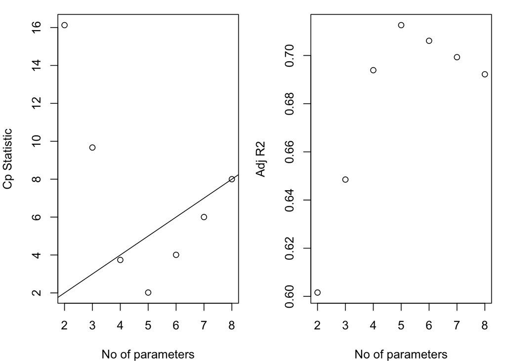

```r
par(mar=c(4,4,1,1))
par(mfrow=c(1,2))

plot(2:8, summary$cp, xlab="No of parameters", ylab="Cp Statistic")
abline(0,1)

plot(2:8, summary$adjr2, xlab="No of parameters", ylab="Adj R2")
```

**Comment**

By doing models compare in terms of AIC, R-adj and Cp, we obtained a model with 5 parameters (4 predictors) because 5 parameters’ model has `Cp` value less than `n` and highest `Adj R2`. In the `Best` table, the best model with 4 predictors is `life_exp ~ murder + hs_grad + frost + population`.

## Problem 4

Compare the two ‘subsets’ from parts 2 and 3 and recommend a ‘final’ model. Using this ‘final’ model do the following:

Answer: Actually, we found the exactly same model from part 2 and 3, which was amazing. Our final model is `life_exp ~ murder + hs_grad + frost + population`.

#### a) Identify any leverage and/or influential points and take appropriate measures.

**Diagnostics Plot**

First, let’s take a look at the plots of our model.

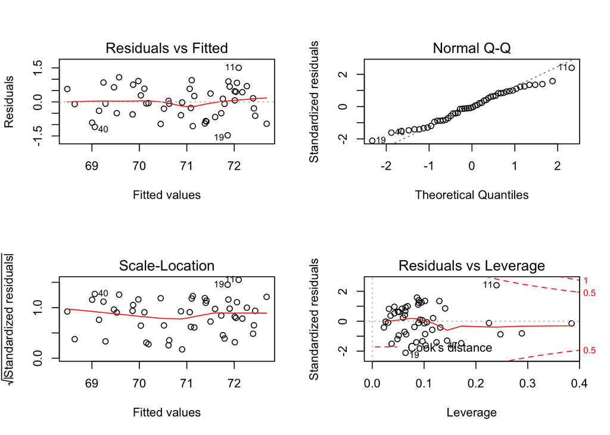

```r
par(mfrow = c(2,2))
plot(fit_final)
```

**Comment**

In `Residuals vs Fitted` and `Quantile–Quantile Plot`, R detect three potential outliers, which are `40`, `19` and `11` observations.

In `Residuals vs Leverage`, R detect some observations at the upper right or lower right corner and cases outside of a dashed line, which are `11`, `47` and `19`.

**Detect outliers in Y using ‘studentized residuals’**

```r
sr = rstandard(fit_final) %>% as_tibble()
outlier_y = sr %>% filter(abs(value) >2.5)
max(abs(sr))
```

```
## [1] 2.401331
```

**Comment**

As the max $R_{i}$ value is `max(abs(sr))`. There are no oulier in Y being detected.

**Detect outliners in X using Leverage values**

```r
fit_hat = hatvalues(fit_final) %>% as_tibble() %>% mutate(n = 1:50)
outlier_x = cbind(fit_hat %>% filter(abs(value) > 0.2),
                 fit_hat %>% filter(abs(value) > (2*5/50)))
names(outlier_x) = c("over_0.2", "observation_n","over_2p/n", "observation_n")
knitr::kable(outlier_x)
```

| over_0.2 | observation_n | over_2p/n | observation_n |
| --- | --- | --- | --- |
| 0.2472792 | 2 | 0.2472792 | 2 |
| 0.3847592 | 5 | 0.3847592 | 5 |
| 0.2397924 | 11 | 0.2397924 | 11 |
| 0.2886092 | 28 | 0.2886092 | 28 |
| 0.2252274 | 32 | 0.2252274 | 32 |

**Comment**

By taking look at the $h_{ii}$ values, we detect five observations with $h_{ii} > 0.2$ and $h{ii} > 2p/n$. They are the same observations: `2`, `5`, `11`, `28`, `32`. They are the potential outliers in X.

**Influencial Observation**

Not all outliers are influential. Therefore, we need to test the influence of the outliers. Using DFFITS test the difference of fitted value with/without an observation and Cook’s Distance to find concerned values.

```r
tb = influence.measures(step_wise)[["infmat"]] %>% as_tibble() %>%
  mutate(n = 1:50) %>%
  select(dffit, cook.d, n) %>%
  filter(abs(dffit)>1|abs(cook.d)>0.5)
knitr::kable(tb)
```

| dffit | cook.d | n |
| --- | --- | --- |
| 1.428239 | 0.3637786 | 11 |

**Comment**

Consider `DFFITS` and `Cook's Distance`, we found out an influencitial outlier `11`. The difference is large between fitted value with/without `11` observation. Next, we can take a look at the change of fitted value with/without `11`.

```r
without11 = state_data[-11,]
fit_with11 = lm(life_exp ~ murder + hs_grad + frost + population, data = state_data)
fit_without11 = lm(life_exp ~ murder + hs_grad + frost + population, data = without11)

sum1 = summary(fit_with11)$coef
sum2 = summary(fit_without11)$coef

(sum1[2]-sum2[2])/sum1[2]
```

```
## [1] 0.0317797
```

```r
(sum1[3]-sum2[3])/sum1[3]
```

```
## [1] 0.1997081
```

```r
(sum1[4]-sum2[4])/sum1[4]
```

```
## [1] 0.4784953
```

```r
(sum1[5]-sum2[5])/sum1[5]
```

```
## [1] -0.2689781
```

**Comment**

After calculating the coefficient changes for each variables, we found that the changes are significant for `hs_grad`, `frost` and `population`. Especially for `frost`, the `frost` value of `11` observation is `0`. It is reasonable for us to consider the possibility of missing value. Therefore, `11` need to be exclude from our dataset.

#### b) Check the model assumptions.

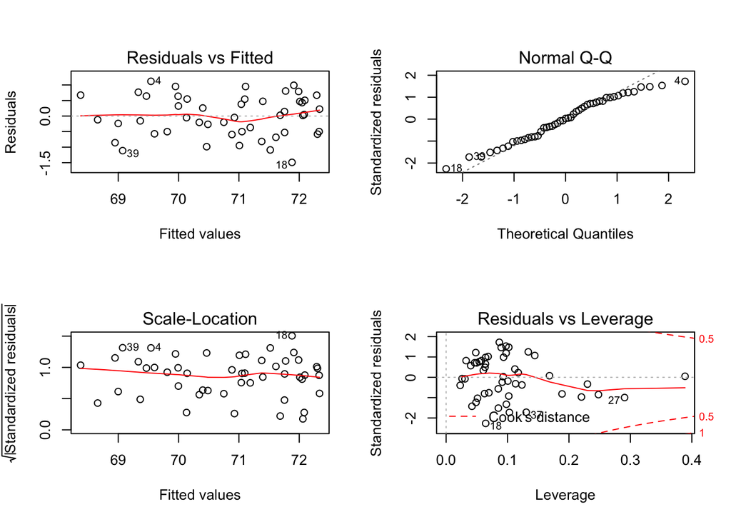

```r
fit_final_without11 = lm(life_exp ~ murder + hs_grad + frost + population, data = without11)

par(mfrow = c(2,2))
plot(fit_final_without11)
```

**Comment**

In the *Residuals vs Fitted Plot* and *Scale-Location Plot*, residual values bounce around 0 and form a horizontal ‘band’ around zero. Our model fulfill equal variance assumption. There are several values stand from the random pattern but they are not problematic.

In the *Quantile–Quantile Plot*, there is a approximately straight line with small departures from normality which are not concerning. There are presence of outliers but they are not concerning with our former test.

In the *Residuals vs Leverage Plot*, there are no outlying values at the upper right or lower right corner, which indicates no influential cases.

## Problem 5

Using the ‘final’ model chosen in part 4, focus on MSE to test the model predictive ability: a) Use a 10-fold cross-validation (10 repeats).